# Initial Principal Component Analysis of Methane Data

Brandon Kim

23 August 2023

## What is the Methane Dataset?

A data set of 70+ existing research papers that contain available soil methane (CH4) flux data

#Read in and clean-up data

library(dplyr) library(tidyr) library(stringr) library(readr) library(udunits2)

current_data <- read_csv(“CH4_8.15.csv”, trim_ws = TRUE, #0 10 20 30 #123456789012345678901234567890123456  
show_col_types = FALSE)

current_data %>% filter(is.na(`Discard?`)) %>% select(-`Discard?`) -> good_data

# Removes all manipulated data which created variability that cannot be accounted for in the PCA

good_data <- good_data[good_data$Manipulation_V2 == “None”, ]

# Unit Counts shows how many of each pre-converted unit there is

good_data %>% group_by(CH4_flux_unit_V2) %>% mutate(count = length(Study_number)) %>% select(CH4_flux_unit_V2, count) %>% unique(.) %>% arrange(desc(count)) -> unit_counts

# Standardizing soil moisture data

# Loop through each row

for (i in 1:nrow(good_data)) { # Check if the SM_unit is not missing and equals “VWC%” if (!is.na(good_data$SM_unit[i]) && good_data$SM_unit[i] == “VWC%”) { # Set default values if PD or BD are missing pd_value <- ifelse(is.na(good_data$PD[i]), 2.65, good_data$PD[i]) bd_value <- ifelse(is.na(good_data$BD[i]), 1.5, good_data$BD[i])

```
# Calculate the new value using the formula
new_value <- good_data$SM_value[i] / (1 - bd_value / pd_value)

# Replace the existing value in SM_value
good_data$SM_value[i] <- new_value
```

} }

#still some conversions to do

#filter out units that we aren’t going to use at this time

good_data %>% select(Study_number, RN, CH4_annual, CH4_growingseason, CH4_monthly, `CH4-C_converted`, Season_converted, N, CH4_flux_unit, CH4_flux_unit_V2, SD_CH4_annual, SD_CH4_growingseason, SD_CH4_monthly) -> for_transformation

for_transformation %>% filter(! is.na(CH4_annual)) %>% mutate(period = “annual”, flux = CH4_annual, flux_sd = SD_CH4_annual) %>% select(- c(CH4_annual, SD_CH4_annual, CH4_growingseason, SD_CH4_growingseason, CH4_monthly, SD_CH4_monthly)) -> annual

for_transformation %>% filter(! is.na(CH4_monthly)) %>% mutate(period = “monthly”, flux = CH4_monthly, flux_sd = SD_CH4_monthly) %>% select(- c(CH4_annual, SD_CH4_annual, CH4_growingseason, SD_CH4_growingseason, CH4_monthly, SD_CH4_monthly))-> monthly

for_transformation %>% filter(! is.na(CH4_growingseason)) %>% mutate(period = “growing season”, flux = CH4_growingseason, flux_sd = SD_CH4_growingseason) %>% select(- c(CH4_annual, SD_CH4_annual, CH4_growingseason, SD_CH4_growingseason, CH4_monthly, SD_CH4_monthly))-> growing_season

annual %>% bind_rows(monthly) %>% bind_rows(growing_season) %>% arrange(Study_number) %>% mutate(converted = ifelse(is.na(Season_converted), `CH4-C_converted`, Season_converted), converted = coalesce(converted, flux), cf = converted/flux, flux_sd = flux_sd*cf) %>% select(-c(`CH4-C_converted`, Season_converted)) -> combined

combined -> tidy_data

tidy_data %>% select(CH4_flux_unit_V2) %>% unique(.)

# 1 mg/m2/h

# 2 kg/ha/yr

# 3 μg/m2/h

# 4 mg/m2/d

# 5 mg/m2/yr

# 6 g/m2/yr

# 7 g/ha/d

# 8 CH4 μmol/mol #this is the only unit that we can’t convert

# 9 kg/hm2/yr

# 10 μg/m2/s

# Unit Conversion with Filtering

# Filter out rows where the original unit is not convertible

convertible_units <- c(“mg/m2/h”, “kg/ha/yr”, “μg/m2/h”, “mg/m2/d”, “mg/m2/yr”, “g/m2/yr”, “g/ha/d”, “μg/m2/s”)

tidy_data %>% filter(CH4_flux_unit_V2 %in% convertible_units) %>% # Only keep rows with convertible units mutate(stnd_flux = ud.convert(converted, CH4_flux_unit_V2, “mg/m2/d”), stnd_flux_sd = ud.convert(flux_sd, CH4_flux_unit_V2, “mg/m2/d”)) %>% select(-c(flux, flux_sd, CH4_flux_unit, CH4_flux_unit_V2, converted, cf)) -> tidy_standard_unit_data

good_data %>% select(Study_number, RN, Study_midyear, Ecosystem_type, Latitude, Longitude, Elevation, SM_value, SM_sd, SM_depth) %>% right_join(tidy_standard_unit_data) -> final_data final_data$Ecosystem_numeric <- as.numeric(as_factor(final_data$Ecosystem_type)) final_data$Period_numeric <- as.numeric(as_factor(final_data$period))

final_data <- final_data %>% select(-SM_sd , -SM_depth,-N, -Longitude, -Study_midyear, -RN, -stnd_flux_sd, -Ecosystem_type, -period) write.csv(final_data, “final_data.csv”, row.names = FALSE)

```
##   Study_number Latitude Elevation  SM_value     stnd_flux Ecosystem_numeric
## 1        23001   39.920        30 0.2691406 -0.9520800000                 1
## 2        23001   39.920        23 0.4362140 -0.0624000000                 1
## 3        23002   10.431       115 0.5242703 -0.0007052174                 1
## 4        23004   33.900        NA 0.4230000 -0.0052800000                 2
## 5        23004   33.900        NA 0.3540000 -0.0081600000                 2
## 6        23004   33.900        NA 0.4940000 -0.0045600000                 2
##   Period_numeric
## 1              1
## 2              1
## 3              2
## 4              2
## 5              2
## 6              2
```

Latitude, Soil Moisture, Standardized CH4 Flux, and Ecosystem type will be assessed in this PCA.

### Linear Regression

Doing a simple linear regression of CH4 soil flux and soil moisture data, we can see a 2-variable comparison of the most obvious sources of variance. However, we know that there is a multitude of factors that contribute to soil methane flux. For this reason, we need a PCA to be able to understand which factors contribute to this variance and to what degree.

```
##
## Call:
## lm(formula = stnd_flux ~ SM_value, data = MethaneData)
##
## Residuals:
##     Min      1Q  Median      3Q     Max
## -4.3753 -0.0631  0.1653  0.4068  1.4340
##
## Coefficients:
##             Estimate Std. Error t value Pr(>|t|)
## (Intercept)  -0.9438     0.2638  -3.578 0.000538 ***
## SM_value      1.2303     0.4342   2.833 0.005585 **
## ---
## Signif. codes:  0 '***' 0.001 '**' 0.01 '*' 0.05 '.' 0.1 ' ' 1
##
## Residual standard error: 0.9169 on 99 degrees of freedom
## Multiple R-squared:  0.075,  Adjusted R-squared:  0.06566
## F-statistic: 8.027 on 1 and 99 DF,  p-value: 0.005585
```

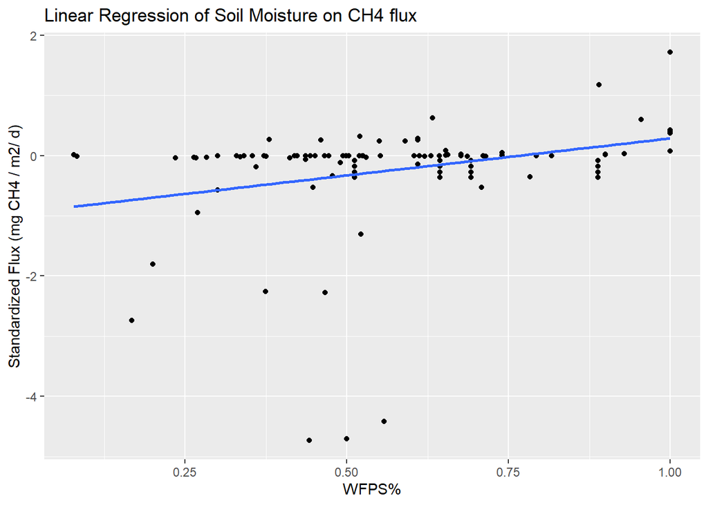

### PRComp

```r
#calculate principal components

# remove period_numeric, study number, and elevation from this pca as they are not relevant to this analysis
MethaneDataNoPeriod <- MethaneData %>% select(-Elevation, -Study_number, -Period_numeric)

# Store pca analysis into "results"
results <- prcomp(MethaneDataNoPeriod, scale = TRUE)
```

Specifying that `scale = TRUE` is critical as it ensures that the variables are correctly scaled on a normal distribution

```r
#reverse the signs
results$rotation <- -1*results$rotation

#display principal components
results$rotation
```

```
##                         PC1        PC2        PC3        PC4
## Latitude          0.3721804 -0.7637237 -0.1219573 -0.5131611
## SM_value          0.4883879  0.5614779  0.3550803 -0.5658072
## stnd_flux         0.5323241  0.2435658 -0.7831530  0.2097097
## Ecosystem_numeric 0.5827436 -0.2052909  0.4956973  0.6103685
```

The above code first flips the values of the eigenvalues with `-1*results$rotation` so that the principal components can be better interpreted.

The output, known as a eigenvalue matrix, shows the correlation between the original variables and the Principal Components.

```
##           PC1        PC2        PC3          PC4
## 1 -1.30216236 -1.3211265 -0.3828782 -0.156945711
## 2 -0.41644610 -0.6484094 -0.8364536 -0.407952506
## 3 -0.50182686  0.2657788 -0.6332466 -0.183988699
## 4 -0.03920446 -0.6889380 -0.5083520  0.193962450
## 5 -0.20041705 -0.8731584 -0.6220080  0.378221361
## 6  0.12542195 -0.4999540 -0.3895493  0.003866711
```

## Biplot of PC1 and PC2

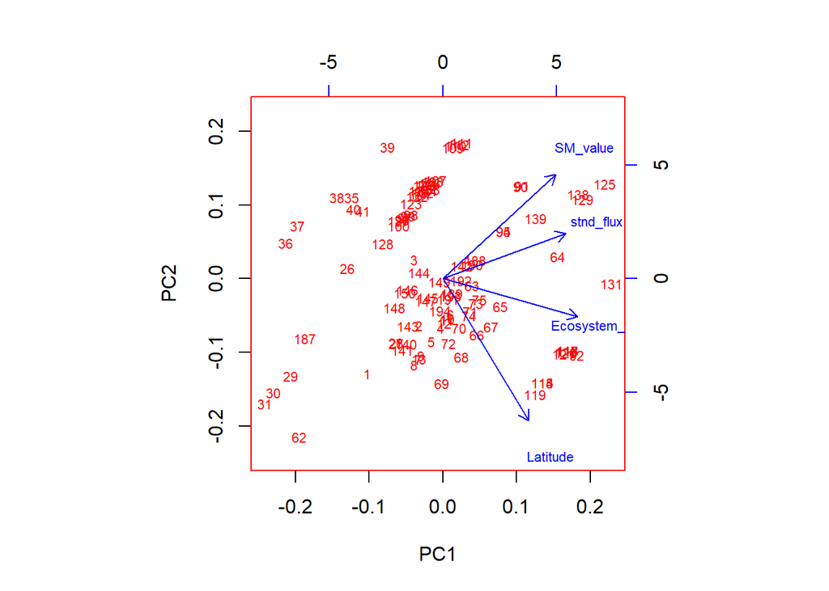

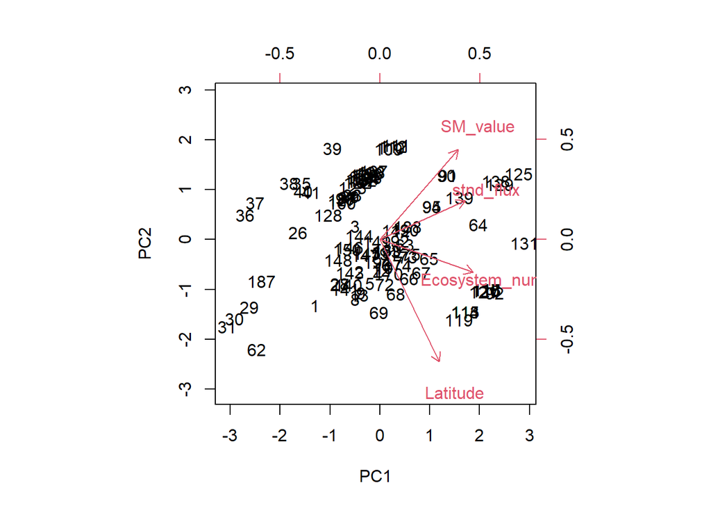

We can better see these eigenvectors on this biplot of the two Principal Components and the relative positions of each variable within them. This shows us how much each PCA can be explained by each variable with a visual example.

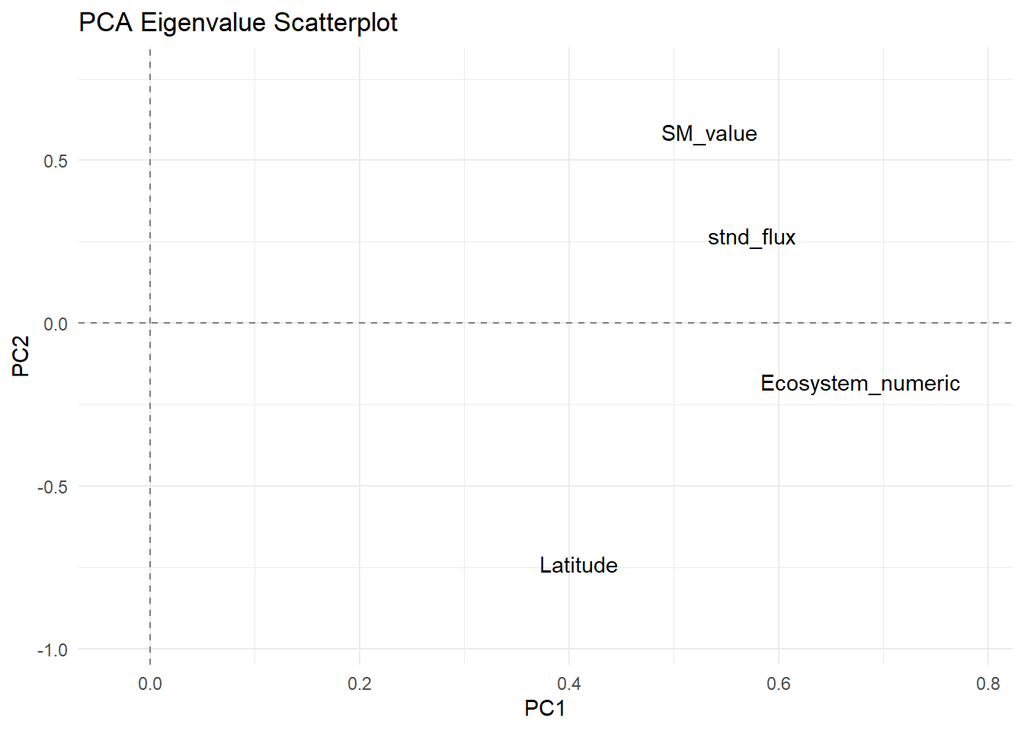

## Scree Plot

We finish this by creating a scree plot, which is a graphic that visualizes the amount of variation that each principal component is responsible for. By doing so, we can see which principal components contribute the most to the results of the dataset.

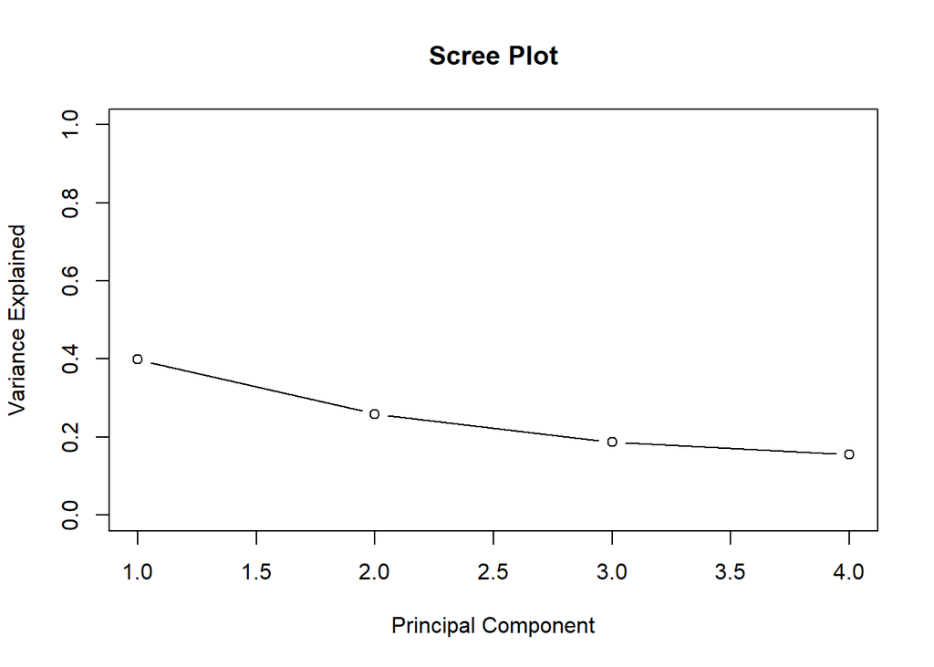

## Summary of PC

```r
summary(results)
```

```
## Importance of components:
##                           PC1    PC2    PC3    PC4
## Standard deviation     1.2621 1.0183 0.8658 0.7877
## Proportion of Variance 0.3982 0.2592 0.1874 0.1551
## Cumulative Proportion  0.3982 0.6575 0.8449 1.0000
```

## References

Zach. (2020, December 1). Principal components analysis in R: Step-by-step example. Statology. https://www.statology.org/principal-components-analysis-in-r/